```python
import os
import pandas as pd
import numpy as np
import matplotlib.pyplot as plt
from matplotlib import colors as mcolors
from sklearn.preprocessing import StandardScaler
from sklearn.model_selection import train_test_split
from sklearn.neighbors import KNeighborsClassifier
from sklearn.metrics import confusion_matrix
import seaborn as sns
import math
```

Tarea 1

```python
def indices_general(MC, nombres = None):
    precision_global = np.sum(MC.diagonal()) / np.sum(MC)
    error_global = 1 - precision_global
    precision_categoria  = pd.DataFrame(MC.diagonal()/np.sum(MC,axis = 1)).T
    if nombres!=None:
        precision_categoria.columns = nombres
    return {"Matriz de Confusión":MC,
            "Precisión Global":precision_global,
            "Error Global":error_global,
            "Precisión por categoría":precision_categoria}

import matplotlib.ticker as mticker

def distribucion_variable_predecir(data:pd.DataFrame,variable_predict:str, ax = None):
    if ax == None:
        fig, ax = plt.subplots(1,1, figsize = (12,6), dpi = 200)
    colors = list(dict(**mcolors.CSS4_COLORS))
    df = pd.crosstab(index=data[variable_predict],columns="valor") / data[variable_predict].count()
    countv = 0
    titulo = "Distribución de la variable %s" % variable_predict
    for i in range(df.shape[0]):
        ax.barh(1,df.iloc[i],left = countv, align='center',color=colors[11+i],label= df.iloc[i].name)
        countv = countv + df.iloc[i]
    ax.set_xlim(0,1)
    ax.set_yticklabels("")
    ax.set_ylabel(variable_predict)
    ax.set_title(titulo)
    ticks_loc = ax.get_xticks().tolist()
    ax.xaxis.set_major_locator(mticker.FixedLocator(ticks_loc))
    ax.set_xticklabels(['{:.0%}'.format(x) for x in ticks_loc])
    countv = 0
    for v in df.iloc[:,0]:
        ax.text(np.mean([countv,countv+v]) - 0.03, 1 , '{:.1%}'.format(v), color='black', fontweight='bold')
        countv = countv + v
    ax.legend(loc='upper center', bbox_to_anchor=(1.08, 1), shadow=True, ncol=1)



def poder_predictivo_categorica(data: pd.DataFrame, var: str, variable_predict: str, ax=None):
    if ax == None:
        fig, ax = plt.subplots(1, 1, figsize=(12, 6), dpi=200)
    df = pd.crosstab(index=data[var], columns=data[variable_predict])
    df = df.div(df.sum(axis=1), axis=0)
    titulo = "Distribución de la variable %s según la variable %s" % (
        var, variable_predict)
    df.plot(kind='barh', stacked=True, legend=True, ax=ax,
            xlim=(0, 1), title=titulo, width=0.8)
    ticks_loc = ax.get_xticks().tolist()
    ax.xaxis.set_major_locator(mticker.FixedLocator(ticks_loc))
    ax.set_xticklabels(['{:.0%}'.format(x) for x in ticks_loc])
    ax.legend(loc='upper center', bbox_to_anchor=(
        1.08, 1), shadow=True, ncol=1)
    for bars in ax.containers:
        plt.setp(bars, width=.9)
    for i in range(df.shape[0]):
        countv = 0
        for v in df.iloc[i]:
            ax.text(np.mean([countv, countv+v]) - 0.03, i,
                    '{:.1%}'.format(v), color='black', fontweight='bold')
            countv = countv + v

def poder_predictivo_numerica(data:pd.DataFrame, var:str, variable_predict:str):
    sns.FacetGrid(data, hue=variable_predict, height=8, aspect=1.8).map(sns.kdeplot, var, shade=True).add_legend()
```

# Pregunta 1: [20 puntos] Dada la siguiente Tabla de Testing de un Scoring de Crédito:

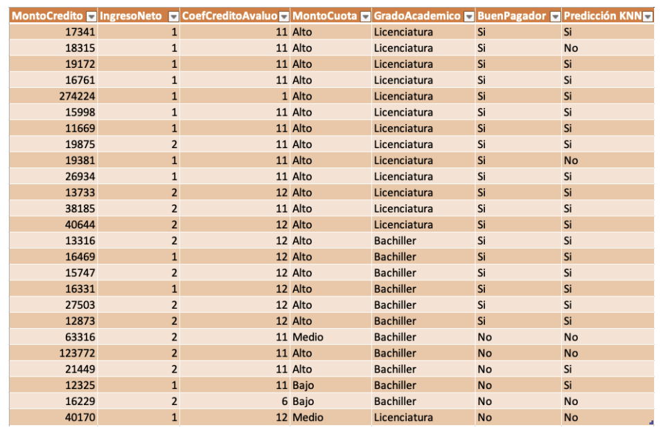

## 1. Usando la columna `BuenPagador` en donde aparece el verdadero valor de la variable a predecir y la columna `Predicción KNN` en donde aparece la predicción del Método KNN para esta tabla de Testing, calcule la Matriz de Confusión.

| MC | NO | SI |
| --- | --- | --- |
| NO | 4 | 2 |
| SI | 2 | 17 |

## 2. Con la Matriz de Confusión anterior calcule “a mano” la Precisión Global, el Error Global, la Precisión Positiva (PP), la Precisión Negativa (PN), la Proporción de Falsos Positivos (PFP), la Proporción de Falsos Negativos (PFN), la Asertividad Positiva (AP) y la Asertividad Negativa (AN).

Precisión Global = $\dfrac {17 + 4}{17 + 4 + 2+2} = \dfrac{21}{25} = 0.84$

Error Global = 1 - PG = $1 - 0.84 = 0.16$

Precisión Positiva = $\dfrac{17}{17+2} = 0.89$

Precisión Negativa = $\dfrac{4}{4+2} = 0.67$

Proporción Falsos Positivos = $\dfrac{2}{4+2} = 0.33$

Proporción Falsos Negativos = $\dfrac{2}{17+2} = 0.10$

Asertividad Positiva = $\dfrac{17}{17+2} = 0.89$

Asertividad Negativa = $\dfrac{4}{4+2} = 0.67$